# The R in Running

Exploratory Data Analysis in R of Garmin Running Log

Steve Cooper

26 February 2018

# The R in Running

In celebration of having recently completed the excellent [Coursera Data Science Specialization](https://www.coursera.org/specializations/jhu-data-science), I’m going to take a few blogs to apply some of my learnings on a hobby dataset. The specialization teaches the basics of getting and cleaning data, exploratory data analysis, reproducibility, statistical inference, regression models, practical machine learning and developing data products. In this blog series I’ll use a similar breakdown, starting here with getting and cleaning data, exploratory data analysis and reproducibility. I’ll cheat on the reproducibility by saying that this entire blog was written in [R Markdown](https://rmarkdown.rstudio.com/) (this code should run for anyone with a Garmin exercise log saved within a local R Studio project folder) and available in Git.

## The Dataset

The dataset that I’ll be using is from my [Garmin Forerunner 620](https://www.dcrainmaker.com/2013/11/garmin-forerunner-review.html). This is a great gadget, providing key [running metrics](https://www.youtube.com/watch?v=kNCnKpLUoAw) on date, distance, calories, time, heart rate, cadence, pace, elevation, stride, vertical oscillation and ground contact time. With [Garmin Connect](https://connect.garmin.com/modern/) runners are able to sync their watch with their online profile, share with e.g. strava. The Garmin Connect interface, however, has a number of shortcomings in terms of exploring your data and developing insights. A perfect use-case for R and bit of data science magic!

The specific question that I want to address is “what influences my overall fitness”? This is fairly loose - I don’t define what fitness is and don’t scope the analysis to specific variables.

# Import the Data

There is a more detailed write-up of the package in Hadley Wickham’s book [“R for Data Science”](http://r4ds.had.co.nz/data-import.html).

```r
# import the file, overriding "TIme" upon import, otherwise it will be set to col_type Time and values lost
activities_raw <- read_csv("Activities_Master.csv",
                           col_types = cols(
                             Date = col_datetime(format = "%d/%m/%Y %H:%M"),
                             Time = col_character(),
                             `Avg Pace` = col_time(format = "%M:%S")
                           ),
                           na = "--")
# some useful readr functions:
# spec(activities_raw) # review parsed column formats
# problems(activities_raw) # review problems during parsing
# activities_raw # review the final "tibble"

# remove spaces from field names
names(activities_raw) <- make.names(names(activities_raw))
```

## Review the Data

Once imported, we are at a point to perform some basic exploration of the dataset via dimension, [five number summary](https://en.wikipedia.org/wiki/Five-number_summary), mean etc. We see the the columns after “Average Ground Contact Time” are largely blank, we can therefore remove them from future analysis.

At this point we can start to explore the dataset, missing data, outliers and categorical variables. This exercise is best performed with the data dictionary to hand. Here we use [Garmin’s Forerunner manual](https://www8.garmin.com/manuals/webhelp/forerunner620/EN-US/GUID-3F11326C-3DE8-4AF2-BC8F-8EA427E9F189.html).

```r
# some basic information (rows and columns)
dim(activities_raw)
```

```
## [1] 112  42
```

```r
# five number summary
# fivenum(activities_raw$`Avg Ground Contact Time`)
summary(activities_raw[,5:10])
```

```
##     Distance         Calories          Time               Avg.HR
##  Min.   : 2.530   Min.   : 141.0   Length:112         Min.   :133.0
##  1st Qu.: 7.995   1st Qu.: 515.8   Class :character   1st Qu.:156.0
##  Median : 9.250   Median : 605.0   Mode  :character   Median :160.5
##  Mean   :10.036   Mean   : 655.6                      Mean   :159.7
##  3rd Qu.:10.877   3rd Qu.: 732.0                      3rd Qu.:165.0
##  Max.   :24.300   Max.   :1425.0                      Max.   :172.0
##      Max.HR        Aerobic.TE
##  Min.   :155.0   Min.   :0.000
##  1st Qu.:178.8   1st Qu.:3.800
##  Median :183.0   Median :4.200
##  Mean   :182.1   Mean   :4.217
##  3rd Qu.:186.0   3rd Qu.:4.800
##  Max.   :192.0   Max.   :5.000
```

```r
# remove blank columns
activities_raw <- select(activities_raw, 1:20)

# review the structure
str(activities_raw[1:5,])
```

```
## Classes 'tbl_df', 'tbl' and 'data.frame':    5 obs. of  20 variables:
##  $ Activity.Type           : chr  "running" "running" "running" "running" ...
##  $ Date                    : POSIXct, format: "2018-02-11 17:48:00" "2017-12-31 13:32:00" ...
##  $ Favorite                : logi  FALSE FALSE FALSE FALSE FALSE
##  $ Title                   : chr  "Dun Laoghaire Running" "Dun Laoghaire Running" "Dun Laoghaire Running" "Dun Laoghaire Running" ...
##  $ Distance                : num  10.4 10.5 10.7 10.5 15.4
##  $ Calories                : num  719 749 744 682 1388
##  $ Time                    : chr  "56:37:00" "56:30:00" "01:00:15" "54:50:00" ...
##  $ Avg.HR                  : int  162 166 157 159 155
##  $ Max.HR                  : int  186 186 182 181 187
##  $ Aerobic.TE              : num  4.8 5 4.1 4.3 4.1
##  $ Avg.Cadence             : int  177 177 177 180 129
##  $ Max.Cadence             : int  185 186 189 193 255
##  $ Avg.Pace                :Classes 'hms', 'difftime'  atomic [1:5] 327 322 338 312 503
##   .. ..- attr(*, "units")= chr "secs"
##  $ Best.Pace               : chr  "04:10" "04:07" "03:41" "02:41" ...
##  $ Elev.Gain               : int  185 181 198 178 848
##  $ Elev.Loss               : int  185 182 183 177 834
##  $ Avg.Stride.Length       : num  1.03 1.05 1 1.07 0.91
##  $ Avg.Vertical.Ratio      : int  0 0 0 0 0
##  $ Avg.Vertical.Oscillation: num  7.3 7.4 7 7.2 13.4
##  $ Avg.Ground.Contact.Time : int  262 255 271 252 380
```

```r
# let's have a look at the first 5 rows of data
head(activities_raw)
```

```
## # A tibble: 6 x 20
##   Activity.Type Date                Favorite Title Distance Calories Time
##   <chr>         <dttm>              <lgl>    <chr>    <dbl>    <dbl> <chr>
## 1 running       2018-02-11 17:48:00 F        Dun ~    10.4       719 56:3~
## 2 running       2017-12-31 13:32:00 F        Dun ~    10.5       749 56:3~
## 3 running       2017-12-28 17:17:00 F        Dun ~    10.7       744 01:0~
## 4 running       2017-11-15 19:12:00 F        Dun ~    10.5       682 54:5~
## 5 trail_running 2017-11-11 10:32:00 F        IMRA~    15.4      1388 02:0~
## 6 track_running 2017-11-06 18:58:00 F        Dun ~     7.95      530 43:1~
## # ... with 13 more variables: Avg.HR <int>, Max.HR <int>, Aerobic.TE
## #   <dbl>, Avg.Cadence <int>, Max.Cadence <int>, Avg.Pace <time>,
## #   Best.Pace <chr>, Elev.Gain <int>, Elev.Loss <int>, Avg.Stride.Length
## #   <dbl>, Avg.Vertical.Ratio <int>, Avg.Vertical.Oscillation <dbl>,
## #   Avg.Ground.Contact.Time <int>
```

```r
# similarly, the last 5 rows of data
tail(activities_raw)
```

```
## # A tibble: 6 x 20
##   Activity.Type Date                Favorite Title Distance Calories Time
##   <chr>         <dttm>              <lgl>    <chr>    <dbl>    <dbl> <chr>
## 1 trail_running 2016-02-05 11:23:00 F        Kilk~     8.18      529 49:5~
## 2 cycling       2016-01-31 13:00:00 F        Bray~    20.0       491 01:0~
## 3 cycling       2016-01-31 11:18:00 F        Kilk~    21.8       699 01:1~
## 4 running       2016-01-30 17:54:00 F        Dun ~     3.67      235 21:04
## 5 running       2016-01-25 18:16:00 F        Dun ~     6.72      419 39:0~
## 6 running       2016-01-23 11:31:00 F        Dun ~     6.22      497 38:1~
## # ... with 13 more variables: Avg.HR <int>, Max.HR <int>, Aerobic.TE
## #   <dbl>, Avg.Cadence <int>, Max.Cadence <int>, Avg.Pace <time>,
## #   Best.Pace <chr>, Elev.Gain <int>, Elev.Loss <int>, Avg.Stride.Length
## #   <dbl>, Avg.Vertical.Ratio <int>, Avg.Vertical.Oscillation <dbl>,
## #   Avg.Ground.Contact.Time <int>
```

```r
# counts - table with means?
table(activities_raw$Activity.Type) # I guess i'm not a cyclist
```

```
##
##       cycling       running track_running trail_running
##             2            93             8             9
```

# Transform the Data

Now that we’ve imported our data, we will perform some basic transformation.

One of the biggest problems with the Garmin data extract is that the `Time` field is in the format of “00:00:00”, but not consistently applied as e.g. mm:ss:cc. A run of 50 minutes, is stored as 50:00:00, whereas a run of 65 minutes is stored as 01:05:00. For this reason, we need to store as character type, seperate and perform some `ifelse()` logic.

We perform some other, simple, transformations, including the creation of categorical variables for elevation gain and [binning](https://www.r-bloggers.com/plot-weekly-or-monthly-totals-in-r/) the `Date` into weeks and months.

Of perhaps more interest is fairly crude calculation of VO2 Max. I can’t for the life of me find my reference site for this calculation. If anyone recognizes it, please let me know so that I can give the author credit!

```r
# Separate "Time" into component parts - converting to integers
activities_tidy <- separate(activities_raw, Time, into = (c("minute", "second", "centisecond")), convert = TRUE)

# Calculate total minutes, if first character is less than 5, treat as an hour unit, else, assume it's in minutes
activities_tidy$tot_mins <- ifelse((activities_tidy$minute < 5),
                                   activities_tidy$minute * 60 + activities_tidy$second,
                                   activities_tidy$minute)

# group elevation gain into categorical variables "high" and "low"
activities_tidy$gain <- ifelse(activities_tidy$Elev.Gain > 250, "high", "low")

# Bin the time series values to weeks and months: https://www.r-bloggers.com/plot-weekly-or-monthly-totals-in-r/
activities_tidy$week <- as.Date(cut(activities_tidy$Date, breaks = "week"))
activities_tidy$month <- as.Date(cut(activities_tidy$Date, breaks = "month"))

# Gauge
#activities_tidy$cadence_gauge <- activities_tidy %>%
#        if (`Avg Cadence` > 183) {return("purple")}

# Calculate #VO2 Max
# calculate meters per minute
activities_tidy$mpm <- (activities_tidy$Distance*1000)/activities_tidy$tot_mins
# calculate VO2
activities_tidy$vo2 <- -4.6+0.182*activities_tidy$mpm+0.000104*activities_tidy$mpm^2
# calculate % VO2 Max
activities_tidy$percentVO2 <- (activities_tidy$Avg.HR/activities_tidy$Max.HR -0.37)/0.64
# calculate VO2 Max
activities_tidy$vo2max <- activities_tidy$vo2/activities_tidy$percentVO2

# check for blanks and n/a
# x0 <- activities_raw$Avg.Cadence
# class(x0)
# str(x0)
# summary(x0) # we can see we have some NA's
# mean(is.na(x0)) # is that missing data a problem?
# mean(is.na(activities_raw))
filter(activities_tidy, is.na(activities_tidy$Avg.Cadence))
```

```
## # A tibble: 2 x 30
##   Activity.Type Date                Favorite Title       Distance Calories
##   <chr>         <dttm>              <lgl>    <chr>          <dbl>    <dbl>
## 1 cycling       2016-01-31 13:00:00 F        Bray Cycli~     20.0      491
## 2 cycling       2016-01-31 11:18:00 F        Kilkeel Cy~     21.8      699
## # ... with 24 more variables: minute <int>, second <int>, centisecond
## #   <int>, Avg.HR <int>, Max.HR <int>, Aerobic.TE <dbl>, Avg.Cadence
## #   <int>, Max.Cadence <int>, Avg.Pace <time>, Best.Pace <chr>, Elev.Gain
## #   <int>, Elev.Loss <int>, Avg.Stride.Length <dbl>, Avg.Vertical.Ratio
## #   <int>, Avg.Vertical.Oscillation <dbl>, Avg.Ground.Contact.Time <int>,
## #   tot_mins <dbl>, gain <chr>, week <date>, month <date>, mpm <dbl>, vo2
## #   <dbl>, percentVO2 <dbl>, vo2max <dbl>
```

```r
# outliers
# normalize VO2 Max
# standard deviation ranges
# sd(activities_tidy$vo2max)
```

## Outliers

# Exploratory Data Analysis

Now the fun starts! We can start testing some of our hypotheses of the data.

## Univariate Analysis

We’ll just look at single dependent variables and understand more about them. If we take VO2 max as the dependent variable, let’s review it.

```r
summary(activities_tidy$vo2max)
```

```
##    Min. 1st Qu.  Median    Mean 3rd Qu.    Max.
##   23.83   36.92   39.29   39.39   41.51   99.38
```

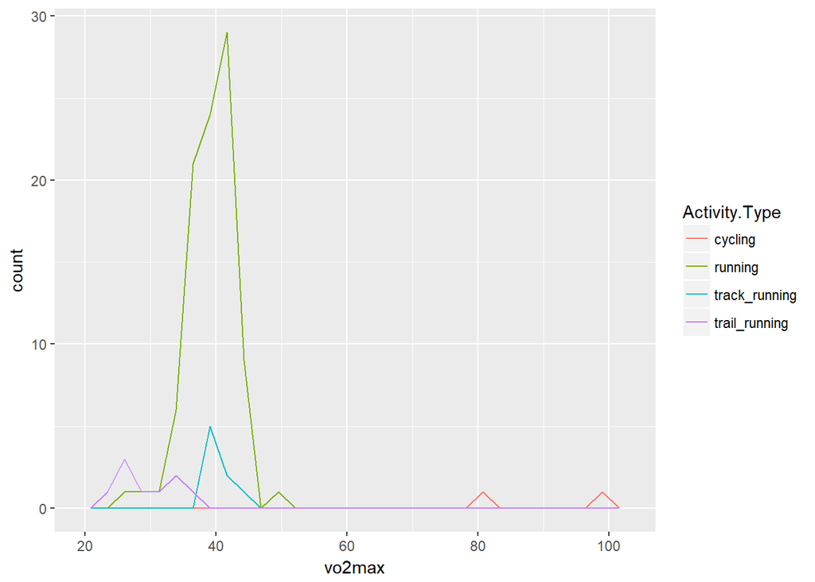

```r
# frequency distribution
activities_tidy %>%
  ggplot(aes(vo2max, color = Activity.Type)) +
  geom_freqpoly()
```

We can see that we have different activity types and that they have different VO2max. Taking all types into account, we see that the data deviates from the normal distribution, has appreciable positive skewness and shows peakedness. Let’s filter cylcing out of our data.

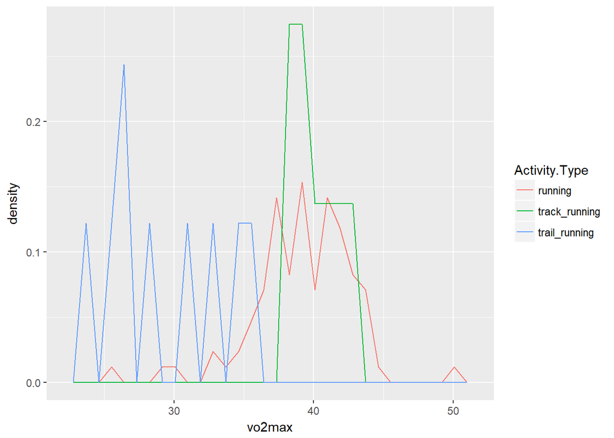

```r
# frequency distribution
activities_tidy %>%
  filter(Activity.Type != "cycling") %>%
  ggplot(aes(vo2max, y = ..density.., color = Activity.Type)) + # note: y has been set to density instead of count
  geom_freqpoly()
```

Still showing skew and peakedness, but less than previously. Given the relatively sparse dataset (only 112 observations), we can assume much of that peakdeness would disappear with more data points. VO2 Max would approach something similar to a normal distribution.

## Multivariate Analysis

Here we’ll try to understand how the dependent and independent variables relate. We will assess both continuous and categorical values.

### Relationship with Numerical Variables

We can see a nice linear relationiship between VO2 Max and Average Pace. I tend to run fastest at a higher VO2 Max. No surprises, however, given that VO2 Max is a function of meters per minute. We’re best to ignore that relationship.

We can see similar linear relationships in Average Cadence. This aligns nicely with running dynamics philosophy that states higher cadence will generally lead to higher run performance.

Unfortunately, whilst there is a linear relationship between VO2 Max and Date, the relationship is rather flat. This is perhaps explained by the fact that my training goes through cycles of enthusiasum and relative laziness.

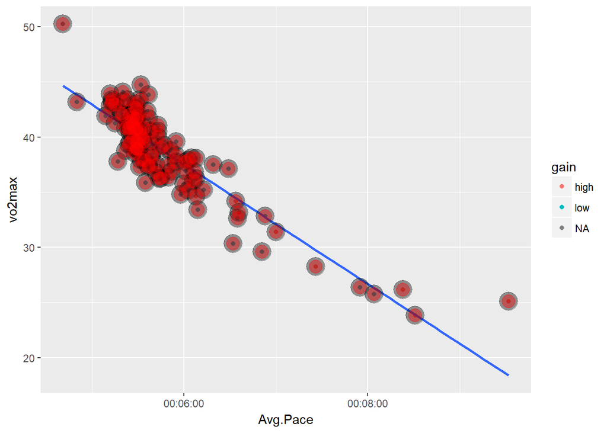

```r
# Plot: We can see a direct relationship between Vo2Max and Average Pace - via scatterplot
activities_tidy %>%
  filter(Activity.Type != "cycling") %>%
  ggplot(mapping = aes(Avg.Pace, vo2max)) +
#        facet_grid(. ~ `Activity Type`) +
  geom_point(mapping = aes(color = gain)) +
  geom_smooth(method = "lm", se = F) +
  geom_point(size = 7, colour = "black", alpha = 0.4) +
  geom_point(size = 5, colour = "red", alpha = 0.4)
```

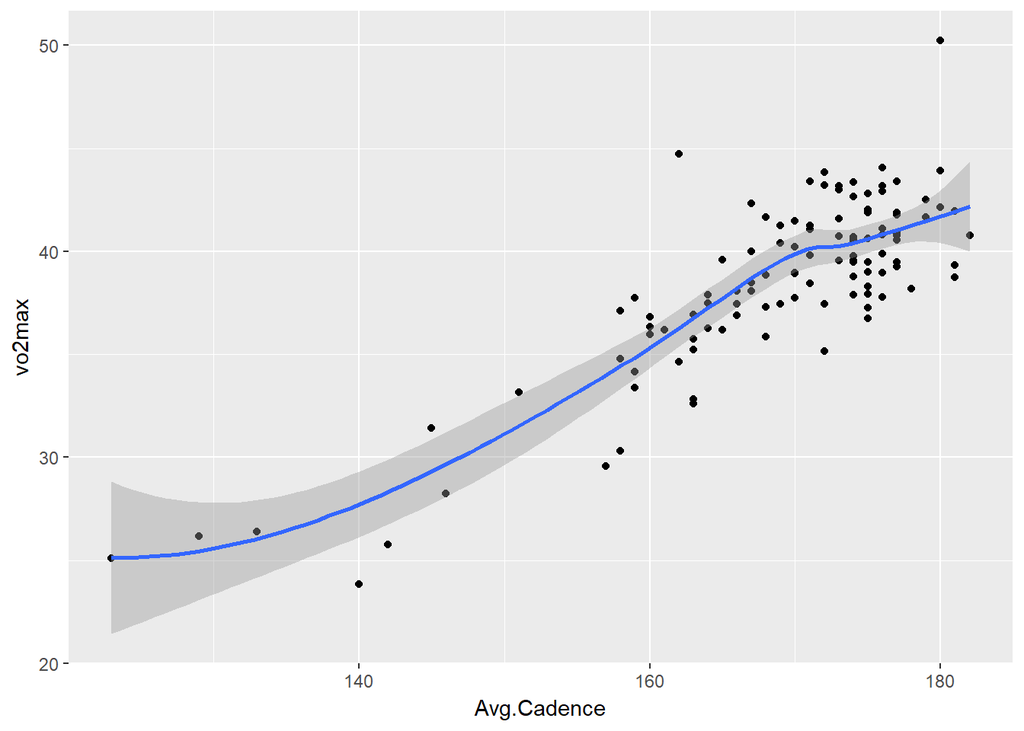

```r
#        geom_jitter() +

activities_tidy %>%
  filter(Activity.Type != "cycling") %>%
  ggplot(mapping = aes(Avg.Cadence, vo2max)) +
  geom_point() +
  geom_smooth()
```

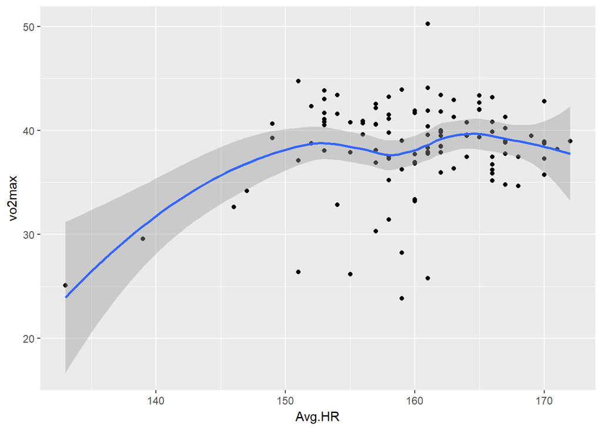

```r
activities_tidy %>%
  filter(Activity.Type != "cycling") %>%
  ggplot(mapping = aes(Avg.HR, vo2max)) +
  geom_point() +
  geom_smooth()
```

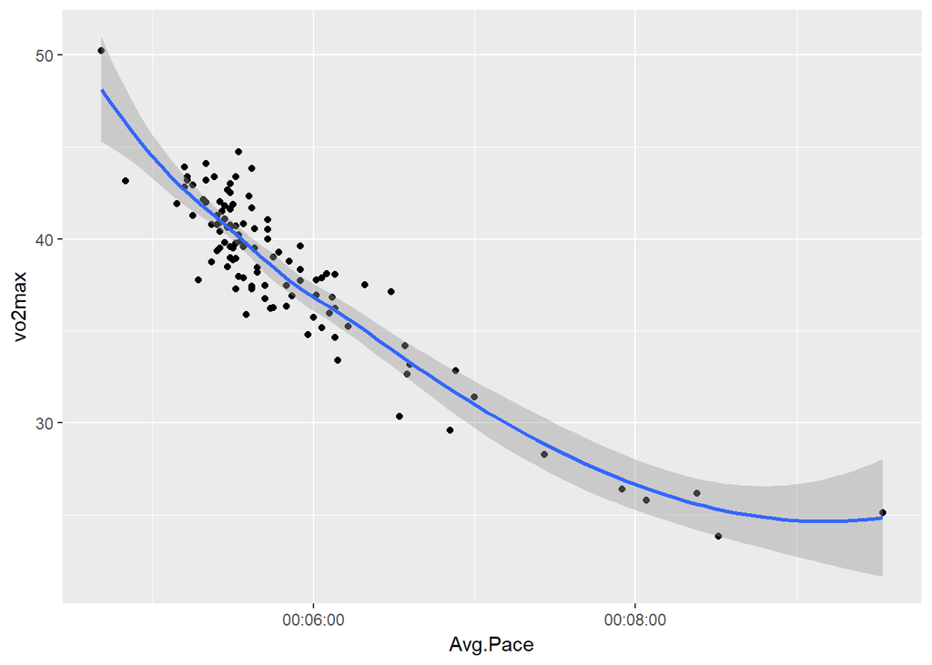

```r
activities_tidy %>%
  filter(Activity.Type != "cycling") %>%
  ggplot(mapping = aes(Avg.Pace, vo2max)) +
  geom_point() +
  geom_smooth()
```

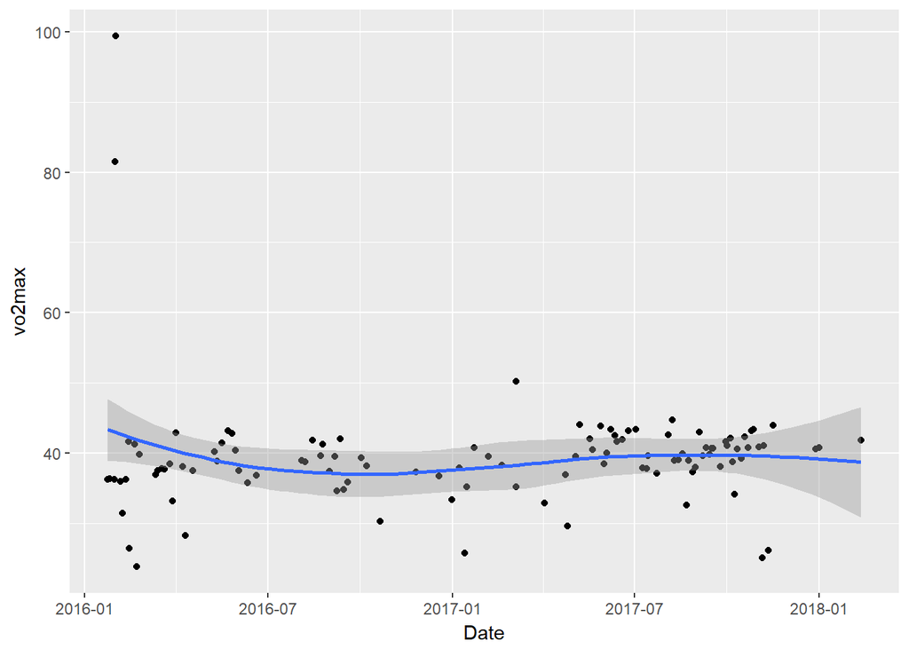

```r
# Plot: Cadence over Time
activities_tidy %>%
        ggplot(mapping = aes(Date, vo2max)) +
        geom_point() +
#       legend ** for the colours
        geom_smooth()
```

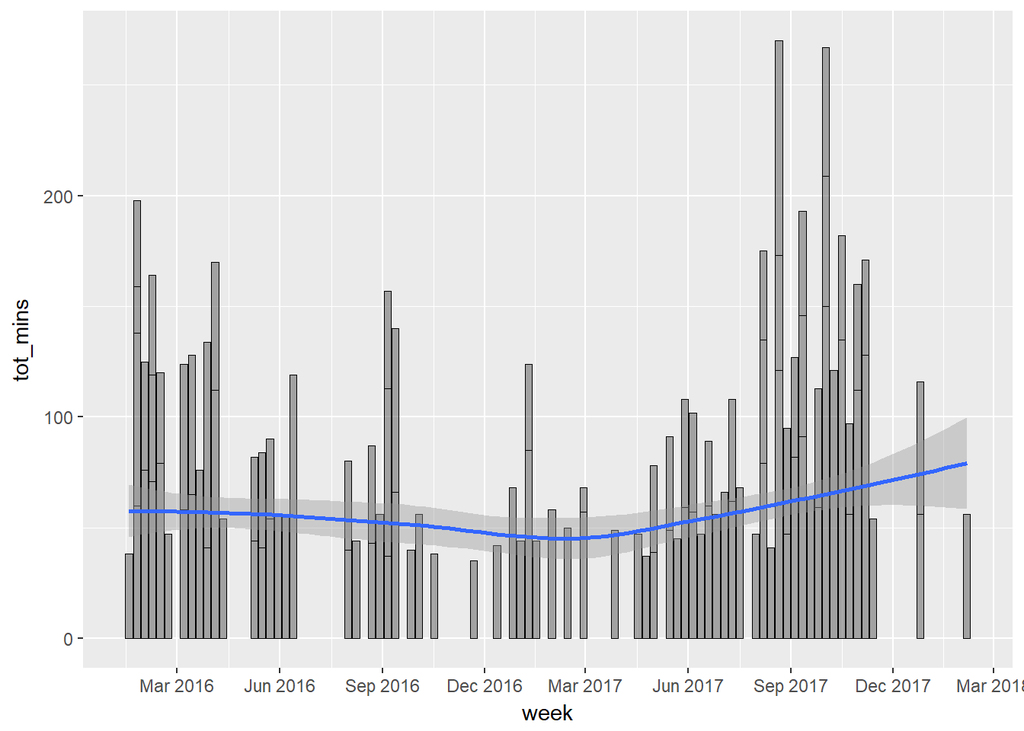

```r
# # Plot: Time and Distance
# # ADD: mean
activities_tidy %>%
        ggplot(aes(week, tot_mins)) +
        geom_bar(color = "black", alpha=.5, size=0, show.legend = NA, stat = ("identity")) +
        geom_smooth() +
        scale_x_date(date_breaks = "3 month", date_labels = "%b %Y")
```

```r
# Some Correlations
cor(activities_tidy$vo2max, activities_tidy$Avg.HR)
```

```
## [1] -0.1582554
```

```r
cor(activities_tidy$vo2max, activities_tidy$Avg.Cadence, use = "pairwise.complete.obs")
```

```
## [1] 0.8392938
```

### Relationship with Categorical Variables

Compared with categorical variables, we can see that my VO2Max is generally higher for my training runs (track and tempo runs) and considerably lower for trail runs. Track runs tend to have a tighter range.

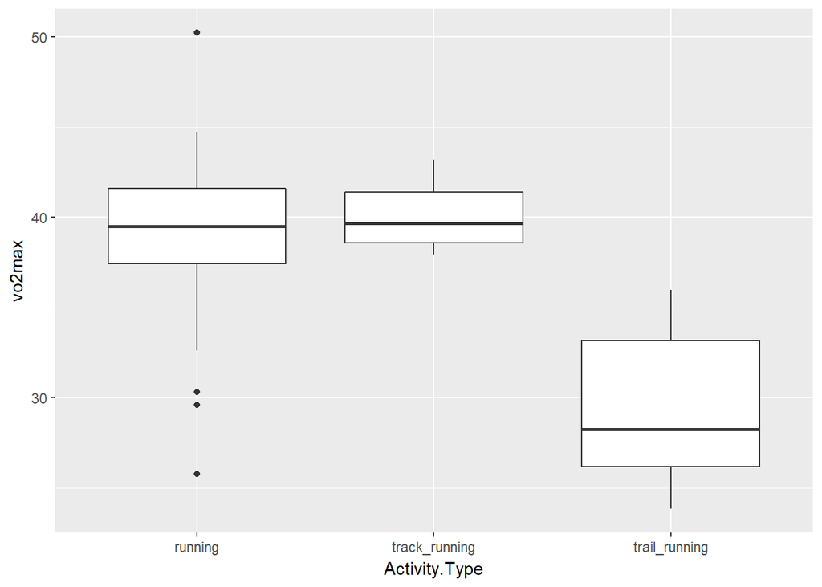

```r
# VO2Max and Run Type
activities_tidy %>%
  filter(Activity.Type != "cycling") %>%
  ggplot(aes(Activity.Type, vo2max)) +
  geom_boxplot()
```

## And the rest of the dataset

Of the 30 or so variables, we have only analysed a handful. These were based upon following our intuition or hypothesis, albeit based upon fairly sound research. We shall now employ broader methods to objectively complete the feature review and selection.

We can see that the people who built the Forerunner knew what they were doing. The running dynamics features of `Average Cadence`, `Vertical Oscillation` and `Ground Contact Time` all have a tight (0.8) correlation with VO2 Max. The former is positive with the latter two being inverse (as vertical oscillation increases, VO2 Max decreases).

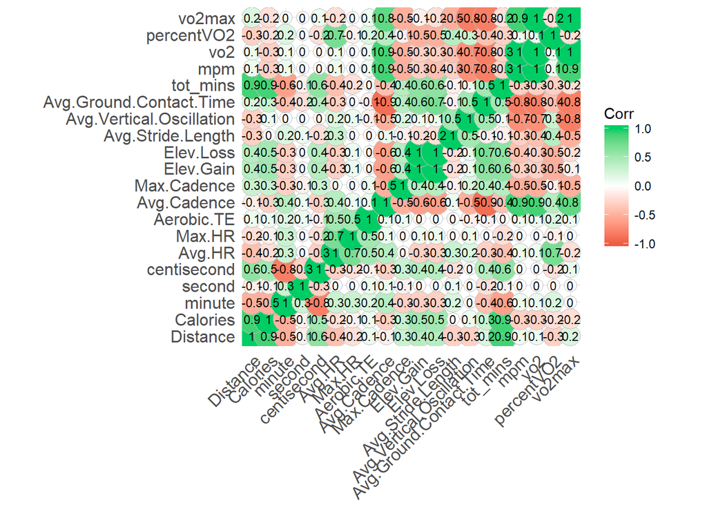

```r
# We can use Correlogram to look at this
nums <- sapply(activities_tidy, is.numeric)
corr <- round(cor(activities_tidy[,nums], use = "pairwise.complete.obs"), 1)
ggcorrplot(corr, lab = T, lab_size = 3, method = "circle", colors = c("tomato2", "white", "springgreen3"))
```

[figure not shown]

```r
# scatter plot for all numeric variables
pairs(activities_tidy[,nums])
```

# Testing our Statistical Inference Assumptions

We saw above that the VO2 Max exhibits largely normal distribution. We can take this further by performing a simple log transformation on the data:

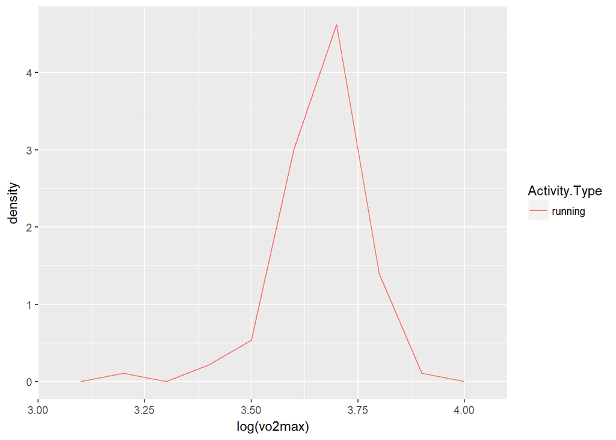

```r
# frequency distribution
activities_tidy %>%
  filter(Activity.Type == "running") %>%
  ggplot(aes(log(vo2max), y = ..density.., color = Activity.Type)) + # note: y has been set to density instead of count
  geom_freqpoly(binwidth = 0.1)
```

# Summary

## Save RData file

Finally, we’ll save our R Data image ready for re-use during our next phase of analysis:

```r
# we can also write to csv
# write_csv(activities_raw, "activities_raw.csv")

# save global environment to RData file
save.image(file = "activities.RData")
```

# Appendix

References:

1. Comprehensive data exploration with python: https://www.kaggle.com/pmarcelino/comprehensive-data-exploration-with-python/
2. R for Data Science: http://r4ds.had.co.nz/
3. R Markdown Cheat Sheet: https://www.rstudio.com/wp-content/uploads/2015/02/rmarkdown-cheatsheet.pdf
4. Exploratory Data Analysis with R: https://bookdown.org/rdpeng/exdata/exploratory-data-analysis-checklist.html
5. Correlogram: http://r-statistics.co/Top50-Ggplot2-Visualizations-MasterList-R-Code.html#Histogram
6. Metrics: https://www.wareable.com/running/your-running-watch-explained-what-does-cadence-vertical-oscillation-and-hr-max-mean
7. Running data: https://www.livescience.com/50706-analyzing-running-data.html
8. Garmin codebook: https://www8.garmin.com/manuals/webhelp/forerunner620/EN-US/GUID-FA8A198E-788C-4E54-83BE-3747FEF7FD2B-homepage.html
9. Histograms and frequency in ggplot: http://ggplot2.tidyverse.org/reference/geom_histogram.html
10. EDA Case Study (Coursera): https://www.youtube.com/watch?v=VE-6bQvyfTQ&list=PLqWwjUXrFNL0I4_tnIbDcVS2V_Z_t5ZLX&t=0s&index=36
11. Scatterplot matrices with ggplot: https://gastonsanchez.wordpress.com/2012/08/27/scatterplot-matrices-with-ggplot/
12. Centering Text in R Markdown: https://stackoverflow.com/questions/24677642/centering-image-and-text-in-r-markdown-for-a-pdf-report
13. Forerunner 620: Running Dynamics with Dr. Jack Daniels: https://www.youtube.com/watch?v=kNCnKpLUoAw